# Week 2: Classic and Digital Marketing Planning

Lecture

Mohammed Ali Sharafuddin

## Week 2 Lecture: Classic and Digital Marketing Planning

Discussion

**1 Recap and Setup**

⏱ 10 min

Week 1 persona review, planning problem framing, six planning questions

Content

**2 Five Theory Pillars**

⏱ 35 min

STP, marketing mix, hierarchy of effects, relationship marketing, ELM, worked canvas example

Practice

**3 Canvas Preview**

⏱ 10 min

Funnel simulator, hierarchy stage identification, positioning statement draft

Assessment

**4 Attendance and Exit Check**

⏱ 5 min

Attendance, Moodle concept check

## Module Arc

**Weeks 1–2**

Foundations and Planning

→

**Weeks 3–5**

Content and Media

→

**Weeks 6–8**

Acquisition Channels

→

**Weeks 9–12**

Relationships and Measurement

→

**Weeks 13–15**

Governance and AI

> **We are still in Weeks 1 and 2: Foundations and Planning.** The persona you built last week is the audience input for today’s planning decisions.

## Today’s Agenda

**Lecture: theory and application**

1. Marketing planning as a decision discipline
2. Segmentation, Targeting, and Positioning (STP)
3. The Marketing Mix: 4Ps and 7Ps
4. Hierarchy of Effects
5. Relationship Marketing
6. The Elaboration Likelihood Model (ELM)
7. Evidence framework applied to planning
8. Worked example: Villa College Canvas

**Tutorial preview**

You will produce a complete first-draft positioning and planning canvas:

- Transfer your Week 1 persona
- Classify hierarchy of effects stage
- Draft two positioning statements
- Select the stronger statement
- Complete channel, message, and metric
- Conduct a short competitive audit
- Peer review before upload

## From Persona to Plan

> A persona tells you who you are trying to reach. A plan tells you what you will change, claim, do, spend, and measure.

**Today we build the plan.**

## Marketing Planning as a Decision Discipline

Marketing planning is the process of making strategic choices before committing resources.

**A plan must answer six questions:**

1. **Who is the target?** A named segment with specific, behavioural criteria.
2. **What will the campaign claim?** A specific, testable point of difference.
3. **How will the claim be delivered?** Channel, format, sequence, and placement.
4. **What resources are required?** Budget, time, creative, and team capacity.
5. **What will be measured?** A primary metric that matches the campaign objective.
6. **What ethical constraints apply?** Data use, targeting scope, and claim accuracy.

## Segmentation, Targeting, and Positioning

> STP is the process of narrowing from a full market to a specific claim for a specific audience in a specific context.

## The STP Process

The three stages are cumulative. Each one narrows the planning problem.

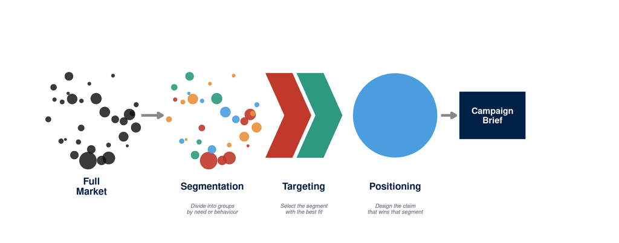

- **Segmentation without targeting** leaves you a map with every route equally valid and none chosen.
- **Targeting without positioning** identifies the audience and leaves the campaign claim unresolved.
- **Positioning without targeting** produces a polished message aimed equally at everyone and compelling to none.

## Positioning Statement Template

A positioning statement structures the claim into four testable components.

> **“For [target segment] who [need or problem], [offering] is the [frame of reference] that [point of difference] because [evidence].”**

**Applied to the Villa College example:**

> “For mid-career marketing and communications professionals in the Greater Male area who need verifiable digital credentials to advance their careers, the Villa College Certificate in Digital Marketing is the only programme in the Maldives that produces a live, open-source analytics portfolio built from a real client or community campaign, evidenced by twelve weeks of structured evidence documentation reviewed by an industry-qualified instructor.”

**Check each element:**

- Target segment: specific, named, behavioural criteria
- Frame of reference: what category you compete in
- Point of difference: what you do better than alternatives in that category
- Evidence: what supports the claim and makes it testable

## STP in the Maldives Context

In the Maldives, segmentation decisions are shaped by the structure of the digital economy.

| Segment | Access pattern | Positioning implication |
| --- | --- | --- |
| **Domestic working adults** (Greater Male) | Mobile-first, social platforms, messaging apps, local community networks | Claims about local relevance, career advancement, and Maldivian employer recognition |
| **International tourist segment** | Review platforms, OTAs, travel aggregators, long-form research sessions | Claims about logistics clarity, peer evidence, and booking confidence |

These two segments require **different positioning claims, different channels, and different evidence standards.**

> Treating them as one audience produces messages too broad to resonate with either.

## Theory Bridge: STP

> **What the theory states:** Campaigns directed at a broadly defined audience produce weaker results because the claim must be too general to be compelling for any specific group.

> **What this changes in your campaign decision:** The planning canvas must name a single primary segment and write a positioning statement that addresses that segment’s specific need, rather than attempting to address every possible audience.

**One canvas. One primary segment. One positioning statement.**

## The Marketing Mix

> The marketing mix is the set of controllable variables that an organisation combines to produce a response in a target market.

## 4Ps Overview

McCarthy introduced the 4Ps framework in 1960. Each element communicates a value signal.

| P | What it controls | Digital expression |
| --- | --- | --- |
| **Product** | What is offered: features, quality, range, warranty | App features, content library, course curriculum, digital service design |
| **Price** | Cost, payment structure, perceived value signal | Pricing page transparency, comparison tool visibility, freemium model |
| **Place** | Where the offering is accessed or delivered | Website, app, platform distribution, OTA listing, marketplace |
| **Promotion** | How the offering is communicated | Ads, content, email, social, influencer, SEO, PR |

> **The consistency test:** does every element of the mix reinforce the positioning claim? A premium promotion claim will fail if the product, price, or delivery process contradicts it.

## 7Ps for Services

Kotler extended the 4Ps for service contexts. Three additional elements apply directly to digital services.

| P | What it controls | Campaign asset or liability |
| --- | --- | --- |
| **Product** | Core service offering and its features | Is the service clearly described and differentiated? |
| **Price** | Cost and value signal | Does the pricing page build confidence or create confusion? |
| **Place** | Delivery channel and access point | Is the digital delivery seamless and mobile-compatible? |
| **Promotion** | Communication and persuasion | Does the creative match the positioning claim? |
| **Process** | How the service is experienced: onboarding, fulfilment, support | Is the learning journey, booking flow, or checkout experience frictionless? |
| **Physical Evidence** | Tangible quality cues in a digital context | Website design, certification logos, testimonials, sample work, data security signals |
| **People** | Staff, instructors, community managers, influencers | Does the team behind the service appear credible and accessible? |

## The 7Ps: Campaign Claim at the Centre

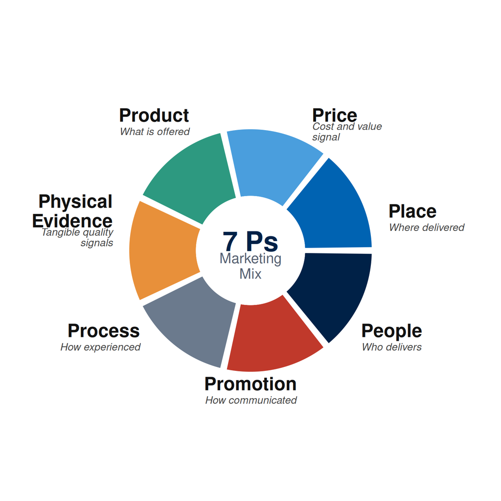

> Each of the seven elements signals value. An inconsistency in any one element undermines the positioning claim at the centre.

## Theory Bridge: Marketing Mix

> **What the theory states:** Each element of the mix communicates a value signal, and those signals must be consistent for the campaign to build trust.

> **What this changes in your campaign decision:** Before writing a headline, audit whether the product, price, delivery process, and physical evidence on the landing page support the claim. An inconsistency discovered after launch is more costly to fix than one discovered during planning.

**Practical check for your canvas:** Read each 7P element against your positioning statement. If any element contradicts the claim, fix it before the campaign goes live.

## Hierarchy of Effects

> The hierarchy of effects model describes the stages through which a consumer moves from ignorance of an offering to its purchase.

**Lavidge and Steiner, 1961.**

## The Six Stages Ladder (Part 1 of 2)

| Stage | Phase | Campaign Objective | Channel Examples |
| --- | --- | --- | --- |
| **Awareness** | Cognitive | Build recognition of the offering in the target segment | Display, social reach campaigns, video pre-roll, digital out-of-home |
| **Knowledge** | Cognitive | Build understanding of what the offering does and why it is relevant | Content marketing, explainer video, FAQ page, search informational |
| **Liking** | Affective | Create a positive emotional response to the offering | Social engagement, testimonials, influencer, community |

> A campaign aimed at a **cold awareness audience** should prioritise reach and recognition above conversion.

## The Six Stages Ladder (Part 2 of 2)

| Stage | Phase | Campaign Objective | Primary Metric |
| --- | --- | --- | --- |
| **Preference** | Affective | Differentiate the offering from alternatives in the audience’s mind | Review ratings, comparison tool visits, return visits |
| **Conviction** | Conative | Overcome final objections and build purchase intent | Click-to-enquiry rate, email open rate, lead quality |
| **Purchase** | Conative | Produce the target action: enquiry, registration, sale, or download | Conversion rate, cost per acquisition, revenue |

> **The metric alignment warning:** using a conversion metric for a cold awareness campaign is both ineffective and misleading, because the metric was never appropriate for the communication goal.

## Hierarchy of Effects: The Complete Ladder

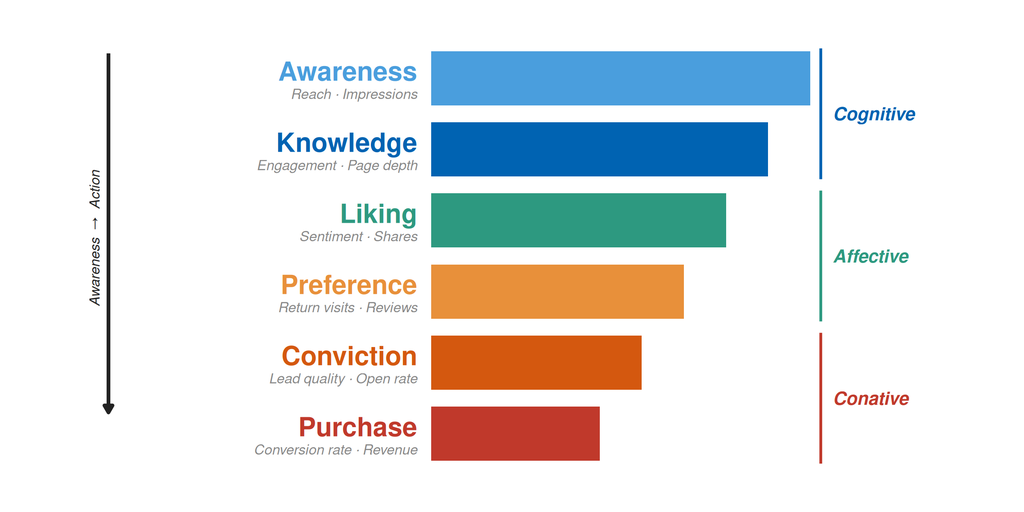

## Theory Bridge: Hierarchy of Effects

> **What the theory states:** Purchase intent requires awareness and knowledge as prerequisites; a campaign skipping those stages will underperform regardless of creative quality.

> **What this changes in your campaign decision:** Before selecting a channel or writing a call to action, estimate which stage the target audience is at and select an objective and metric that matches that stage. A misaligned metric misleads the campaign team about whether the work is succeeding.

**Your canvas must name the hierarchy stage and justify it with evidence or label it as an assumption.**

## Relationship Marketing

> Relationship marketing shifts the focus from individual transactions to sustained exchange relationships.

**Gronroos, 1994. Morgan and Hunt, 1994.**

## Acquisition vs Retention

**Acquisition campaign**

Goal: bring new customers into a first contact.

- Channels: paid search, display, organic social, OTA listing
- Message: proof, offer, clear call to action
- Metric: conversion rate, cost per acquisition
- Promise: a one-time benefit (discount, event, product feature)

**Retention campaign**

Goal: sustain and deepen relationships with existing customers.

- Channels: email, CRM, loyalty programme, community
- Message: value, community, exclusive access, progressive skill-building
- Metric: repeat engagement, net promoter score, customer lifetime value
- Promise: consistent value over time (guidance, community, expertise)

> In Maldivian SME contexts, relationship marketing is often the more appropriate framework. Repeat custom and word-of-mouth recommendation drive significant revenue in markets where social trust is high and reputation travels quickly through community networks.

## Acquisition vs Retention: Campaign Architecture

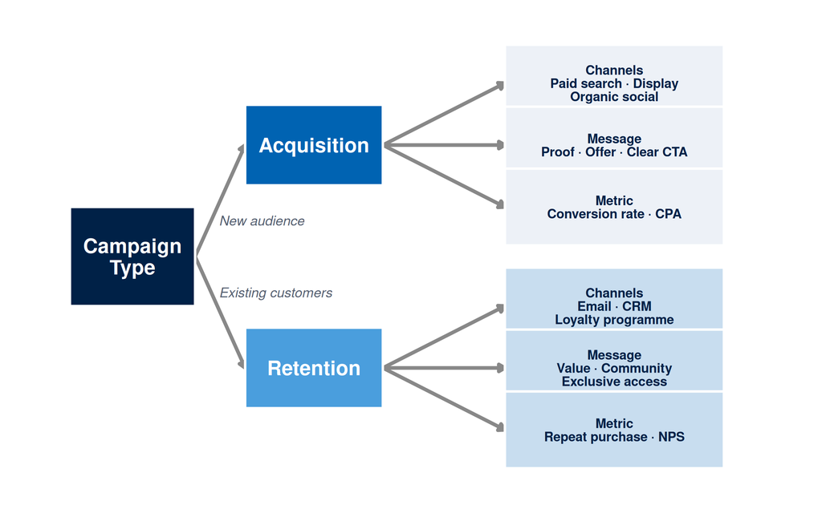

## Theory Bridge: Relationship Marketing

> **What the theory states:** The most valuable marketing outcome is often a sustained relationship that generates repeat behaviour and referral, extending well beyond the initial transaction.

> **What this changes in your campaign decision:** The planning canvas must specify whether the campaign is designed for acquisition or retention, because the channel, message, and metric are fundamentally different for each purpose.

**Ask yourself: am I trying to reach someone new, or deepen a connection with someone who already knows us?**

## Elaboration Likelihood Model

> The ELM proposes two routes through which persuasion occurs: central (careful argument evaluation) and peripheral (cues and heuristics).

**Petty and Cacioppo, 1986.**

## Central Route vs Peripheral Route

**Central route**

Condition: high motivation and ability to process the message.

What the audience does: carefully evaluates the argument, compares evidence, considers objections.

What the campaign must provide: detailed information, evidence, testimonials from credible sources, arguments that address real objections.

Outcome: durable attitude change, strong behaviour intention.

Example: a professional considering a postgraduate programme, a business evaluating software, a parent choosing a school.

**Peripheral route**

Condition: low motivation or low ability to process carefully.

What the audience does: relies on cues, heuristics, and surface signals rather than careful reasoning.

What the campaign must provide: strong design, positive reviews prominently displayed, familiar endorser, social proof, scarcity signal.

Outcome: weaker attitude change, more susceptible to counter-argument.

Example: choosing between two comparable products at similar price, browsing a social platform at low-attention moments.

## ELM and Message Design Decisions

The same audience member can shift between routes depending on context.

| Context | Likely route | Message design required |
| --- | --- | --- |
| Searching “best MSc in digital marketing Maldives” | Central: high involvement, problem-solving mode | Argument, evidence, curriculum detail, instructor credentials, answers to objections |
| Scrolling social platform at low-attention moment | Peripheral: browsing, open to content but not deciding | Strong design, social proof, concise claim, visual clarity |
| Re-reading an email from a programme they are seriously considering | Central: evaluation mode | Testimonials from credible sources, specific outcomes, objection handling |
| Seeing a retargeted ad after visiting the programme page | Peripheral or transitioning to central | Social proof, scarcity signal, simple call to action |

> A high-involvement segment requires argument, evidence, and answers to objections. A low-involvement context requires salient cues. **Using the wrong message design for the expected route wastes the creative investment.**

## ELM: Two Routes to Attitude Change

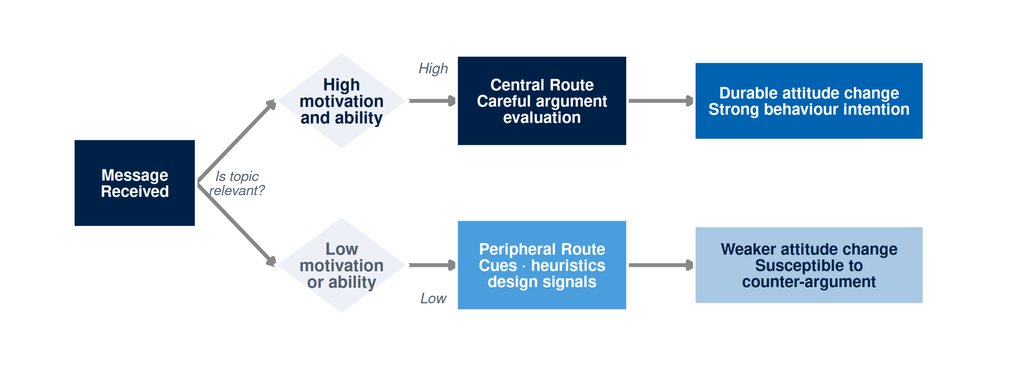

## Theory Bridge: ELM

> **What the theory states:** The persuasion route depends on the audience’s motivation and ability to process information, and central-route persuasion produces more durable attitude change.

> **What this changes in your campaign decision:** The planning canvas must match message depth to processing route. A high-involvement segment requires argument, evidence, and answers to objections. A low-involvement context requires salient cues. Using the wrong message design for the expected route wastes the creative investment.

**Canvas entry: ELM processing route (central or peripheral) with a two-sentence justification.**

## Evidence Framework Applied to Planning

Every element of the positioning and planning canvas should be classified using the four-category framework from Week 1.

| Canvas Element | Evidence (if available) | Assumption (if evidence absent) | Testing Method |
| --- | --- | --- | --- |
| Target segment | Documented search signals, platform community data, survey results | Defined by logic but not yet verified with public signals | Search trend analysis, platform audience insights, short survey |
| Hierarchy stage | Awareness survey, branded search volume, direct audience research | Estimated from market context rather than measured directly | Brand lift survey, keyword comparison, focus group |
| Positioning claim | Competitor claim audit, audience language from reviews or forums | Point of difference believed relevant but not tested | A/B message test, social listening, user interview |
| Channel selection | Platform reach data, audience device data, competitor channel mapping | Selected based on general knowledge rather than segment-specific evidence | Small-budget platform test before full deployment |
| Primary metric | Historical conversion data, industry benchmark, previous campaign results | Selected by analogy with similar campaigns, not baseline data | Historical benchmark research or pre-launch pilot |

## Worked Example: Villa College Canvas Preview

**Case A: Certificate in Digital Marketing, Villa College (fictional campaign)**

Key decisions from applying the five frameworks:

- **Segment identified:** mid-career marketing and communications professionals in Greater Male, aged 25 to 40, with credential gaps in digital skills and professional motivation to address them. Based on Google Trends data, LinkedIn profile review, and job advertisement analysis.
- **Hierarchy stage:** audience is at Knowledge stage (aware that certificates exist; preference still forming). Campaign objective: knowledge and preference-building, with conversion as a later-stage goal.
- **Positioning claim:** the only Maldivian programme that produces a live, open-source analytics portfolio from a real campaign. Point of difference assumed based on competitive landscape; requires verification.
- **ELM route:** Central. High-involvement career investment. Message must include curriculum detail, instructor credentials, and objection handling (schedule compatibility, cost justification, qualification credibility).
- **Channel plan:** organic search and LinkedIn sponsored content for awareness and knowledge; email to permission list and retargeting for preference and conviction.
- **Primary metrics:** time on page for programme description and curriculum page; branded search volume for institution name. These indicate whether the audience is engaging with central-route decision content.

## Funnel Simulator: Use the Interactive Tool

The web book chapter includes a **Digital Marketing Funnel Simulator** that connects directly to the hierarchy of effects model.

**How to use it in context of today’s lecture:**

1. Open the Week 2 chapter in the web book (your module reading platform)
2. Scroll to the Interactive Lab section
3. Set the sliders to match the estimates in your canvas
4. Observe which stage produces the largest drop-off
5. Ask: is that drop-off a creative problem, a targeting problem, or a hierarchy mismatch?

> A very low landing page conversion rate on a cold awareness campaign may simply mean the audience was not yet ready to convert: a hierarchy mismatch rather than a page design problem.

**Each funnel stage maps to a hierarchy of effects stage.** The simulator makes visible why a campaign with a well-defined objective and metric at the right stage outperforms one that optimises for the wrong conversion goal.

## Key Takeaways

- **A plan converts the persona into decisions.** The persona describes who you are targeting; the plan decides what you will claim, where, with what message, and measured by what metric.
- **STP narrows the problem.** Segmentation without targeting produces a directionless map. Targeting without positioning leaves the claim unresolved.
- **The marketing mix must be internally consistent.** A premium claim is undermined by a poor landing page, a confusing price, or a weak process experience.
- **The hierarchy stage determines the metric.** A conversion metric applied to a cold awareness campaign produces misleading data about whether the work is succeeding.
- **Acquisition and retention campaigns require different channels, messages, and metrics.** Mixing them produces uninterpretable results.
- **ELM route determines message depth.** A high-involvement audience requires argument and evidence; peripheral cues alone will fail to persuade.

## Preview of Week 3

> **Next week:** how visual design and image choice serve the positioning claim, and why the aesthetic layer of a campaign is also a strategic decision.

**For the tutorial today, bring your Week 1 persona notes.**